# EDA of the Red Wine Data Set by Todd Allen

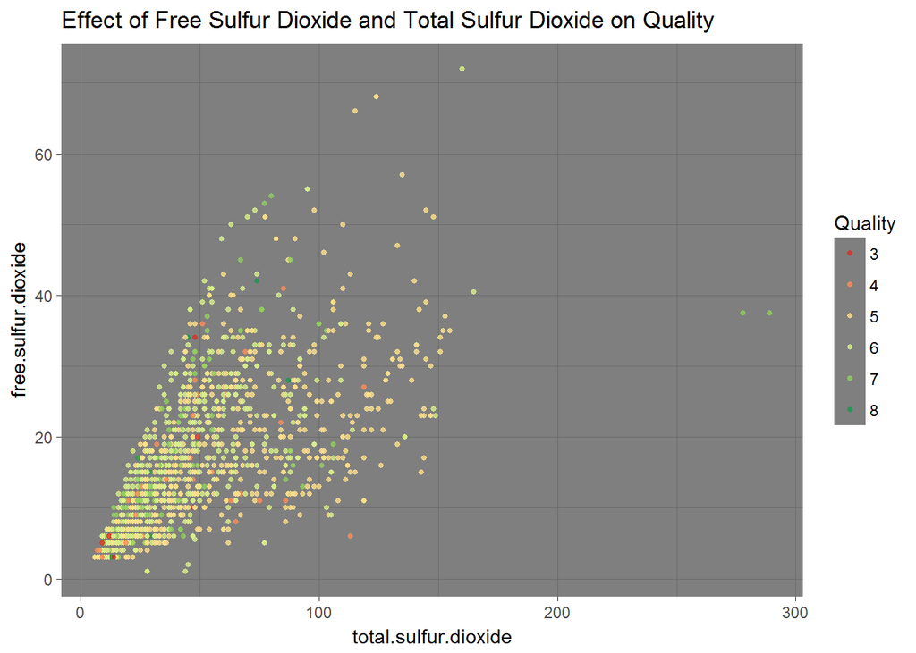

No correlation with quality given the positive correlation between free and total sulfur dioxide.

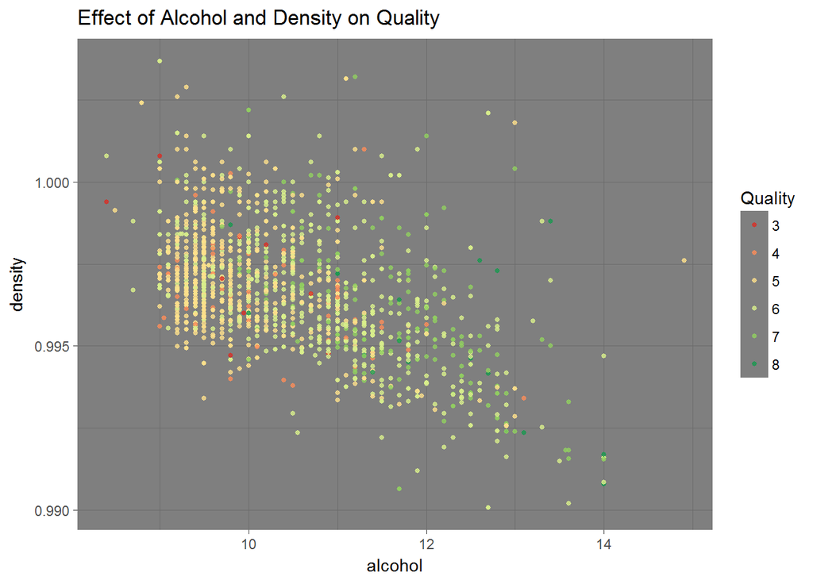

Here there does seem to be some correlation with quality as there are more data points for the better quality wines as the alcohol increases and then density decreases, although I fell this is a stretch.

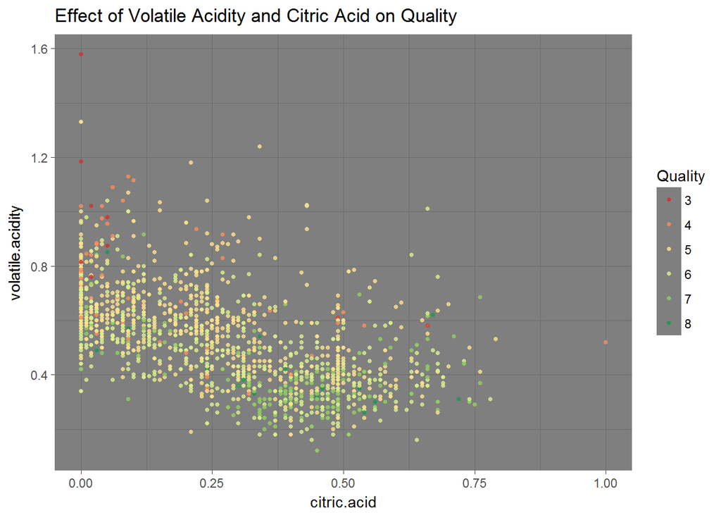

There does seem to be a small correlation on quality when volatile acidity decreases and citric acid increases. However, this is a small correlation.

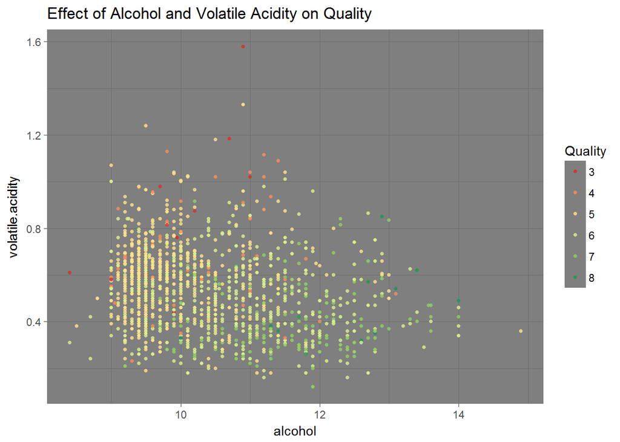

```r
ggplot(data = df_wine, aes(y = volatile.acidity, x = alcohol, color = quality_factor)) +
  geom_point(alpha = 0.8, size = 1) +
  scale_color_brewer(palette="RdYlGn",
                   guide=guide_legend(title='Quality')) +
  theme_dark() +
  ggtitle('Effect of Alcohol and Volatile Acidity on Quality')
```

This shows a negative correlation between alcohol percentages and volative acidity and an increase in quality as a result.

### Linear model comparing Volatile Acidity, Alcohol and Sulphates with Quality

```
##
## Calls:
## m1: lm(formula = as.numeric(quality) ~ alcohol, data = df_wine)
## m2: lm(formula = as.numeric(quality) ~ alcohol + volatile.acidity,
##     data = df_wine)
## m3: lm(formula = as.numeric(quality) ~ alcohol + volatile.acidity +
##     sulphates, data = df_wine)
##
## ==============================================================
##                          m1            m2            m3
## --------------------------------------------------------------
##   (Intercept)           1.875***      3.095***      2.611***
##                        (0.175)       (0.184)       (0.196)
##   alcohol               0.361***      0.314***      0.309***
##                        (0.017)       (0.016)       (0.016)
##   volatile.acidity                   -1.384***     -1.221***
##                                      (0.095)       (0.097)
##   sulphates                                         0.679***
##                                                    (0.101)
## --------------------------------------------------------------
##   R-squared             0.227         0.317         0.336
##   adj. R-squared        0.226         0.316         0.335
##   sigma                 0.710         0.668         0.659
##   F                   468.267       370.379       268.912
##   p                     0.000         0.000         0.000
##   Log-likelihood    -1721.057     -1621.814     -1599.384
##   Deviance            805.870       711.796       692.105
##   AIC                3448.114      3251.628      3208.768
##   BIC                3464.245      3273.136      3235.654
##   N                  1599          1599          1599
## ==============================================================
```

### Linear model comparing Volatile Acidity with Quality

```
##
## Calls:
## m1: lm(formula = as.numeric(quality) ~ volatile.acidity, data = df_wine)
##
## ==================================
##   (Intercept)           6.566***
##                        (0.058)
##   volatile.acidity     -1.761***
##                        (0.104)
## ----------------------------------
##   R-squared             0.153
##   adj. R-squared        0.152
##   sigma                 0.744
##   F                   287.444
##   p                     0.000
##   Log-likelihood    -1794.312
##   Deviance            883.198
##   AIC                3594.624
##   BIC                3610.756
##   N                  1599
## ==================================
```

### Linear model comparing Sulphates with Quality

```
##
## Calls:
## m1: lm(formula = as.numeric(quality) ~ sulphates, data = df_wine)
##
## ================================
##   (Intercept)         4.848***
##                      (0.078)
##   sulphates           1.198***
##                      (0.115)
## --------------------------------
##   R-squared           0.063
##   adj. R-squared      0.063
##   sigma               0.782
##   F                 107.740
##   p                   0.000
##   Log-likelihood  -1874.438
##   Deviance          976.300
##   AIC              3754.876
##   BIC              3771.008
##   N                1599
## ================================
```

### Linear model comparing Alcohol with Quality

```
##
## Calls:
## m1: lm(formula = as.numeric(quality) ~ alcohol, data = df_wine)
##
## ================================
##   (Intercept)         1.875***
##                      (0.175)
##   alcohol             0.361***
##                      (0.017)
## --------------------------------
##   R-squared           0.227
##   adj. R-squared      0.226
##   sigma               0.710
##   F                 468.267
##   p                   0.000
##   Log-likelihood  -1721.057
##   Deviance          805.870
##   AIC              3448.114
##   BIC              3464.245
##   N                1599
## ================================
```

The R-squared value does increase as you add more features to the model but overall the three top features only contribute to 34% of the wine quality.

# Multivariate Analysis

### Talk about some of the relationships you observed in this part of the investigation. Were there features that strengthened each other in terms of looking at your feature(s) of interest?

These plots suggest that not even a combination of features in this data set would have a big influence on the quality of the wine even though the correlation between features have correlations. It seems we are missing an important feature from the data set that contirbutes the most to the quality of the wine.

### Were there any interesting or surprising interactions between features?

THe interaction between pH and Votatile Aciditcy was suprising as acid and pH should have a negative correlation but in this case there is a slightly positive correlation.

# Final Plots and Summary

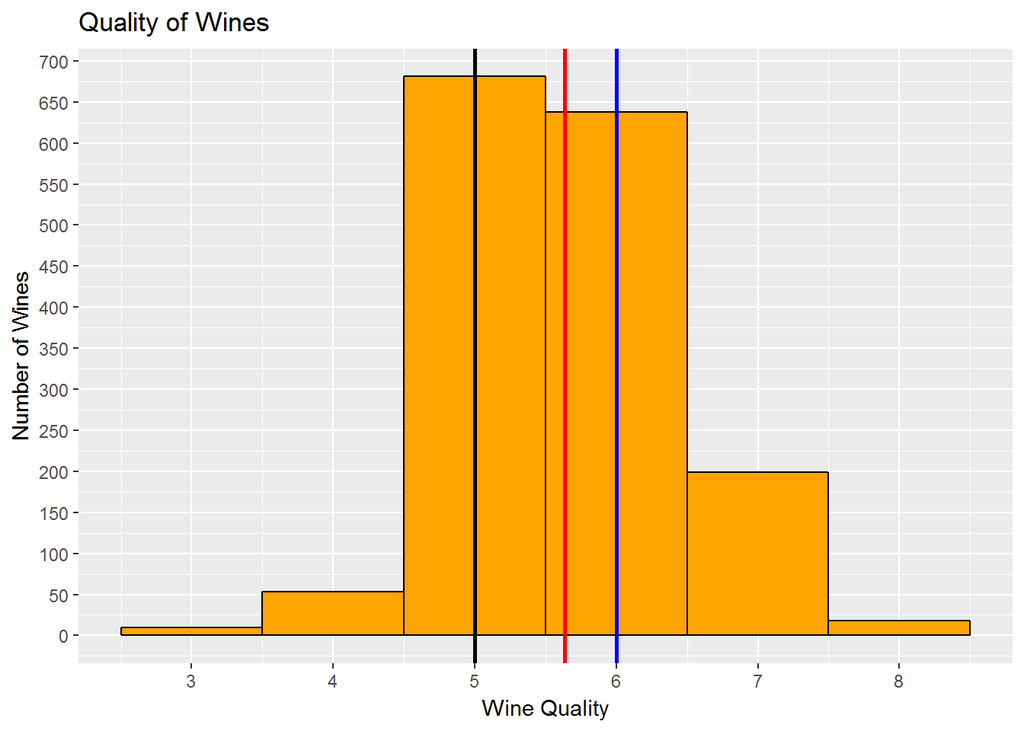

### Description One

Most of wines in this data set are in the average range of quality, with ratings of 5 and 6. There does not seem to be a good amount of wines on the lower or upper ends of the quality ratings to get a good idea of how the current features affect those types of wines.

### Plot Two - Feature Selection

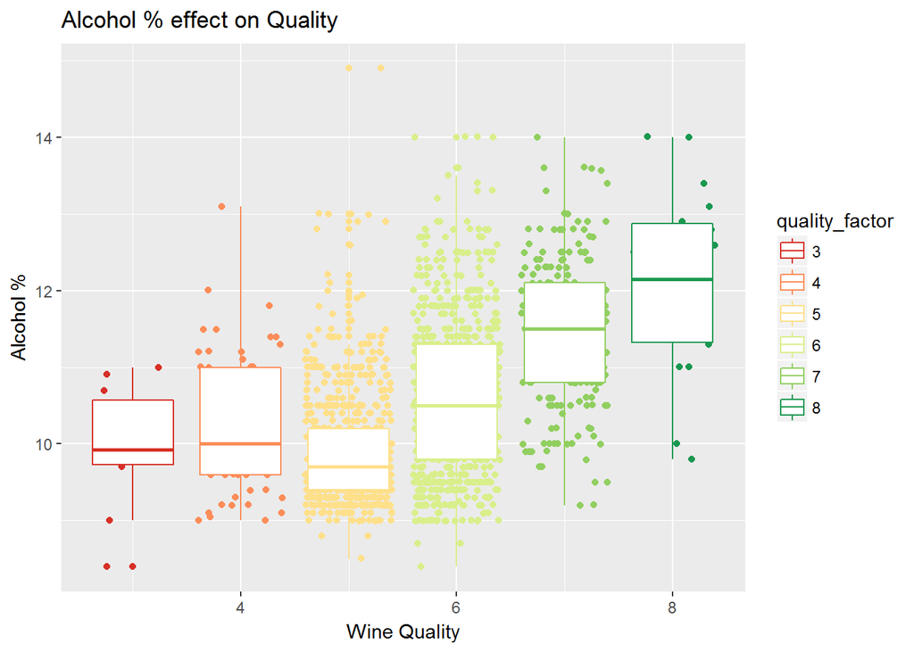

### Description Two

The alcohol % does increase as teh quality of the wine increases. It would be interesting to see the alcohol percentage of wines in the 9 and 10 quality rating.

### Plot Three - Alcohol Effect on Quality Scatter

[figure not shown]

# Reflection

It seems that this dataset is lacking data in that there were not enough samples from the lower and upper quality ratings. Also, from my research the grape determines the quality of the wine more than any other feature. It would be beneficial to include information about the grape as far as harvest season, region, and type of grape. It would also be beneficial to know what type of wine as far as merlot, pino noir, zinfandel, etc. Along with the grape type and wine type, it may also be interesting to have each judges selection to see if he or she favors one wine over another. The only surprising discovery is that the volatile acidity and pH have positive correlation. Overall, there was not any overwelming evidence that would suggest the any one feature or multiples of these features have a big impact on the quality of the wine. At this point, quality is based on the expert’s subjective perspective based on taste.